# L'Hopitals Rule

Let's return to limits of the form $f(x)/g(x)$ which have an indeterminate form of $0/0$ if both are evaluated at $c$. The typical example being the limit considered by Euler:

$$~ \lim_{x\rightarrow 0} \frac{\sin(x)}{x}. ~$$

We know this is $1$ using a bound from geometry, but might also guess this is one, as we know from linearization near $0$ that we have

$$~ \sin(x) = x - \sin(\xi)x^2/2, \quad 0 < \xi < x. ~$$

This would yield:

$$~ \lim_{x \rightarrow 0} \frac{\sin(x)}{x} = \lim_{x\rightarrow 0} \frac{x -\sin(\xi) x^2/2}{x} = \lim_{x\rightarrow 0} 1 + \sin(\xi) \cdot x/2 = 1. ~$$

This is because we know $\sin(\xi) x/2$ has a limit of $0$, when $|\xi| \leq |x|$.

That doesn't look any easier, as we worried about the error term, but if just mentally replaced $\sin(x)$ with $x$ – which it basically is near $0$ – then we can see that the limit should be the same as $x/x$ which we know is $1$ without thinking.

Basically, we found that in terms of limits, if both $f(x)$ and $g(x)$ are $0$ at $c$, that we *might* be able to just take this limit: $(f(c) + f'(c) \cdot(x-c)) / (g(c) + g'(c) \cdot (x-c))$ which is just $f'(c)/g'(c)$.

Wouldn't that be nice? We could find difficult limits just by differentiating the top and the bottom at $c$ (and not use the messy quotient rule).

Well, in fact that is more or less true, a fact that dates back to [L'Hopital](http://en.wikipedia.org/wiki/L%27H%C3%B4pital%27s_rule) – who wrote the first textbook on differential calculus – though this result is likely due to one of the Bernoulli brothers.

> **L'Hopital's rule**: Suppose, $f$ and $g$ are differentiable in $(a,b)$ with $a < c < b$. Moreover, suppose $g(x) > 0$ for all $x$ in $(a,b)$ except at $c$. Further suppose $f(c)=g(c) =0$. If $\lim_{x\rightarrow c}f'(x)/g'(x)=L$ (the limit exists), then $L = \lim_{x \rightarrow c}f(x)/g(x)$.

That is *if* the limit of $f(x)/g(x)$ is indeterminate of the form $0/0$, but the limit of $f'(x)/g'(x)$ is known, possibly by simple continuity, then the limit of $f(x)/g(x)$ exists and is equal to that of $f'(x)/g'(x)$.

To apply this rule to Euler's example, $\sin(x)/x$, we just need to consider that:

$$~ 1 = \lim_{x \rightarrow 0}\frac{\cos(x)}{1} ~$$

This is due to $\cos(x)$ being continuous at $0$, so this limit is just $\cos(0)/1$. (More importantly, the tangent line expansion of $\sin(x)$ at $0$ is $\sin(0) + \cos(0)x$, so that $\cos(0)$ is why this answer is as it is, but we don't need to think in terms of $\cos(0)$, but rather the tangent-line expansion, which is $\sin(x) \approx x$, as $\cos(0)$ appears as the coefficient.

##### Examples

- Consider this limit at $0$: $(a^x - 1)/x$. We have $f(x) =a^x-1$ has $f(0) = 0$, so this limit is indeterminate of the form $0/0$. The derivative of $f(x)$ is $f'(x) = a^x \log(a)$ which has $f'(0) = 1$. The derivative of the bottom is also $1$ at $0$, so we have:

$$~ 1 = \frac{1}{1} = \frac{f'(0)}{g'(0)} = \lim_{x \rightarrow 0}\frac{f'(x)}{g'(x)} = \lim_{x \rightarrow 0}\frac{f(x)}{g(x)} = \lim_{x \rightarrow 0}\frac{a^x - 1}{x}. ~$$

(Why rewrite in the "opposite" direction? Because the theorem's result ($L$ is the limit) is only true if the related limit involving the derivative exists.)

- Consider this limit:

$$~ \lim_{x \rightarrow 0} \frac{e^x - e^{-x}}{x}. ~$$

It too is of the indeterminate form $0/0$. The derivative of the top is $e^x + e^{-x}$, which is $2$ when $x=0$, so the ratio of $f'(0)/g'(0)$ is seen to be 2. By L'Hopital's rule, the limit above is $2$.

- Sometimes, L'Hopital's rule must be applied twice. Consider this limit:

$$~ \lim_{x \rightarrow 0} \frac{\cos(x)}{1 - x^2} ~$$

By L'Hopital's rule *if* this following limit exists, the two will be equal:

$$~ \lim_{x \rightarrow 0} \frac{-\sin(x)}{-2x}. ~$$

But if we didn't guess the answer, we see that this is indeterminate of the form $0/0$. So that limit will exist and be equal to this limit, should it exist:

$$~ \lim_{x \rightarrow 0} \frac{-\cos(x)}{-2} = 1/2. ~$$

As $L = 1/2$ for this related limit, it must also be the limit of the original problem, by L'Hopital's rule.

- Our "intuitive" limits can bump into issues. Take for example the limit of $(\sin(x)-x)/x^2$ as $x$ goes to $0$. Using $\sin(x) \approx x$ makes this look like $0/x^2$ which is still indeterminate. (Because the difference is higher order than $x$.) Using L'Hopitals, says this limit will exist (and be equal) if the following one does:

$$~ \lim_{x \rightarrow 0} \frac{\cos(x) - 1}{2x}. ~$$

This particular limit is indeterminate of the form $0/0$, so we again try L'Hopital's rule and consider

$$~ \lim_{x \rightarrow 0} \frac{-\sin(x)}{2} = 0 ~$$

So as this limit exists, working backwards, the original limit in question will also be $0$.

- This example comes from the Wikipedia page. It "proves" a discrete approximation for the second derivative.

Show if $f''(x)$ exists at $c$ and is continuous at $c$, then

$$~ f''(c) = \lim_{h \rightarrow 0} \frac{f(c + h) - 2f(c) + f(c-h)}{h^2}. ~$$

This will follow from two applications of L'Hopital's rule to the right hand side. The first says, the limit on the right is equal to this limit, should it exist:

$$~ \lim_{h \rightarrow 0} \frac{f'(c+h) - 0 - f'(c-h)}{2h}. ~$$

We have to be careful, as we differentiate in the $h$ variable, not the $c$ one, so the chain rule brings out the minus sign. But again, as we still have an indeterminate form $0/0$, this limit will equal the following limit should it exist:

$$~ \lim_{h \rightarrow 0} \frac{f''(c+h) - 0 - (-f''(c-h))}{2} = \lim_{c \rightarrow 0}\frac{f''(c+h) + f''(c-h)}{2} = f''(c). ~$$

That last equality follows, as it is assumed that $f''(x)$ exists at $c$ and is continuous, that is, $f''(c \pm h) \rightarrow f''(c)$.

The expression above finds use when second derivatives are numerically approximated. (The middle expression is the basis of the central-finite difference approximation to the derivative.)

## Why?

The proof of L'Hopital's rule takes advantage of Cauchy's [generalization](http://en.wikipedia.org/wiki/Mean_value_theorem#Cauchy.27s_mean_value_theorem) of the mean value theorem to two functions. Let $f(x)$ and $g(x)$ be continuous on $[a,b]$ and differentiable on $(a,b)$ so that on $[c,c+x]$ there exists a $\xi$ with $f'(\xi) \cdot (f(x) - f(c)) = g'(c) \cdot (g(x) - g(c))$. In our formulation, both $f(c)$ and $g(c)$ are zero, so we have, provided we know that $g(x)$ is non zero, that $f(x)/g(x) = f'(\xi)/g'(\xi)$ for some $\xi$, $c < \xi < c + x$. That the right hand side has a limit as $x \rightarrow c+$ is true by the assumption that the limit of the derivative's ratio exists. (The $\xi$ part can be removed by considering it as a composition of a function going to $c$.) Thus the right limit of the left hand side is known. Similarly, working with $[c-x, c]$ we can get the left limit is known and is equal to the right.

### L'Hopital's picture

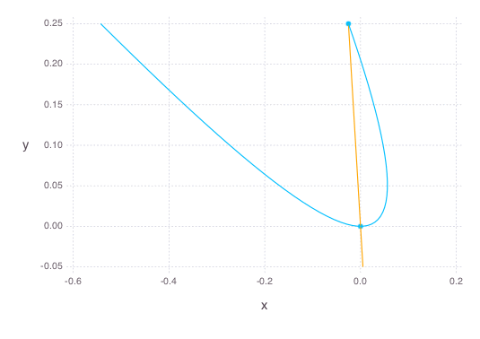

Geometric interpretation of $L=\lim_{x \rightarrow 0} x^2 / (\sqrt{1 + x} - 1 - x^2)$. At $0$ this limit is indeterminate of the form $0/0$. The value for a fixed $x$ can be seen as the slope of a secant line of a parametric plot of the two functions, plotted as $(g, f)$. In this figure, the limiting "tangent" line has $0$ slope, corresponding to the limit $L$. In general, L'Hopital's rule is nothing more than a statement about slopes of tangent lines.

## Generalizations

L'Hopital's rule generalizes to other indeterminate forms, in particular $\infty/\infty$ can be proved at the same time as $0/0$ with a more careful proof.

In addition, indeterminate forms of the type $0 \cdot \infty$, $0^0$ and $\infty^\infty$ can be re-expressed to be in the form $0/0$ or $\infty/\infty$.

For example, consider

$$~ \lim_{x \rightarrow \infty} \frac{x}{e^x}. ~$$

We see it is of the form $\infty/\infty$ (That we are taking a limit at $\infty$ is also a generalization.) We have by the generalized L'Hopital rule that this limit will exist and be equal to this one, should it exist:

$$~ \lim_{x \rightarrow \infty} \frac{1}{e^x}. ~$$

This limit is, of course, $0$, as it is of the form $1/\infty$. It is not hard to build up from here to show that for any integer value of $n>0$ that:

$$~ \lim_{x \rightarrow \infty} \frac{x^n}{e^x} = 0. ~$$

This is an expression of the fact that exponential functions grow faster than polynomial functions.

##### Examples

- What is the limit $x \log(x)$ as $x \rightarrow 0+$?

Rewriting, we see this is just:

$$~ \lim_{x \rightarrow 0+}\frac{\log(x)}{1/x}. ~$$

L'Hopital's rule clearly applies to one sided limits, as well as two (our proof sketch used one-sided limits), so this limit will equal the following, should it exist:

$$~ \lim_{x \rightarrow 0+}\frac{1/x}{-1/x^2} = \lim_{x \rightarrow 0+} -x = 0. ~$$

- What is the limit $x^x$ as $x \rightarrow 0+$? The expression is of the form $0^0$, which is indeterminate. (Even though floating point math defines the value as $1$.) We can rewrite this by taking a log:

$$~ x^x = \exp(\log(x^x)) = \exp(x \log(x)) = \exp(\log(x)/(1/x)). ~$$

Be just saw that $\lim_{x \rightarrow 0+}\log(x)/(1/x) = 0$. So by the rules for limits of compositions and the fact that $e^x$ is continuous, we see $\lim_{x \rightarrow 0+} x^x = e^0 = 1$.

- L'Hopital himself was interested in this limit for $a > 0$

$$~ \lim_{x \rightarrow a} \frac{\sqrt{2a^3\cdot x-x^4} - a\cdot(a^2\cdot x)^{1/3}}{ a - (a\cdot x^3)^{1/4}}. ~$$

These derivatives can be done by hand, but to avoid any minor mistakes we utilize `SymPy` taking care to use rational numbers for the fractional powers, so as not to lose precision through floating point roundoff:

```julia
using SymPy
a,x = symbols("a, x", positive=true, real=true)
f(x) = sqrt(2a^3*x - x^4) - a * (a^2*x)^(1//3)
g(x) = a - (a*x^3)^(1//4)
```

```
g (generic function with 1 method)
```

We can see that at $x=a$ we have the indeterminate form $0/0$:

```julia
f(a), g(a)
```

```
(0,0)
```

What about the derivatives?

```julia
fp, gp = subs(diff(f(x),x), x, a), subs(diff(g(x),x), x, a)
```

```
(-4*a/3,-3/4)
```

Their ratio will not be indeterminate, so the limit in question is just the ratio:

```julia
fp/gp
```

$$\frac{16 a}{9}$$

Of course, we could have just relied on `limit`, which knows about L'Hopital's rule:

```julia
limit(f(x)/g(x), x, a)
```

$$\frac{16 a}{9}$$

## Questions

###### Question

This function $f(x) = \sin(5x)/x$ is *indeterminate* at $x=0$. What type?

$0/0$

$\infty/\infty$

$0^0$

$\infty - \infty$

$0 \cdot \infty$

###### Question

This function $f(x) = \sin(x)^{\sin(x)}$ is *indeterminate* at $x=0$. What type?

$0/0$

$\infty/\infty$

$0^0$

$\infty - \infty$

$0 \cdot \infty$

###### Question

This function $f(x) = (x-2)/(x^2 - 4)$ is *indeterminate* at $x=2$. What type?

$0/0$

$\infty/\infty$

$0^0$

$\infty - \infty$

$0 \cdot \infty$

###### Question

This function $f(x) = (g(x+h) - g(x-h)) / (2h)$ ($g$ is continuous) is *indeterminate* at $h=0$. What type?

$0/0$

$\infty/\infty$

$0^0$

$\infty - \infty$

$0 \cdot \infty$

###### Question

This function $f(x) = x \log(x)$ is *indeterminate* at $x=0$. What type?

$0/0$

$\infty/\infty$

$0^0$

$\infty - \infty$

$0 \cdot \infty$

###### Question

Does L'Hopital's rule apply to this limit:

$$~ \lim_{x \rightarrow \pi} \frac{\sin(\pi x)}{\pi x}. ~$$

Yes. It is of the form $0/0$

No. It is not indeterminate

###### Question

Use L'Hopital's rule to find the limit

$$~ L = \lim_{x \rightarrow 0} \frac{4x - \sin(x)}{x}. ~$$

What is $L$?

###### Question

Use L'Hopital's rule to find the limit

$$~ L = \lim_{x \rightarrow 0} \frac{\sqrt{1+x} - 1}{x}. ~$$

What is $L$?

###### Question

Use L'Hopital's rule *two* or more times to find the limit

$$~ L = \lim_{x \rightarrow 0} \frac{x - \sin(x)}{x^3}. ~$$

What is $L$?

###### Question

Use L'Hopital's rule *two* or more times to find the limit

$$~ L = \lim_{x \rightarrow 0} \frac{1 - x^2/2 - \cos(x)}{x^3}. ~$$

What is $L$?

###### Question

By using a common denominator to rewrite this expression, use L'Hopital's rule to find the limit

$$~ L = \lim_{x \rightarrow 0} \frac{1}{x} - \frac{1}{\sin(x)}. ~$$

What is $L$?